# Влияние различных параметров квартиры на формирование её стоимости

(по данным агрегатора NMarket.pro по городу Санкт-Петербург за 19.06.2019)

Никита Снегирев

05.10.2019

## Введение

Данное исследование посвящено рынку недвижимости в городе Санкт-Петербурге. За основу взяты данные из агрегатора объектов недвижимости по данному городу. Предварительно в исследование закладывалось три задачи. Первая, найти неочевидные соотношения между параметрами квартиры и ценой. Вторая, определить есть ли существенные различия в цене меду апартаментами и квартирами. И, третья, это проверить как этажность дома соотносится с его ценой. Предварительно было сформировано две гипотезы. Первая — общий консенсус касательно цен на апартамены, предполагается, что они дешевше, в среднем, чем квартиры. Вторая гипотеза о том, что квартиры в низкоэтажной застройке 3-6-9 этажей дороже, чем высотная. В ходе исследования обе гипотезы были опровергнуты. Кроме того, были проанализированы, также, и другие показатели, например, стоимость жилого комплекса и материал из которого он построен. Ниже будут представлены графики и результаты статистических тестов, с подробным описанием. За основу взята только цена за квадратный метр, чтобы сократить размер работы, без потери для содержательных выводов.

### Объект исследования

В качестве объекта исследования были взяты жилые комплексы, тех застройщиков, которые сотрудничают с агрегатором NMarket. Из тех, что были доступны для бронирования на момент 19.06.2019 была сделана выборка. На каждый ЖК приходится в среднем 89 квартир.

На графике ниже вы можете увидеть распределение жилых комплексов по районам. Цветовое обозначение позволяет более четко визуально раличать районы Санкт-Петербурга.

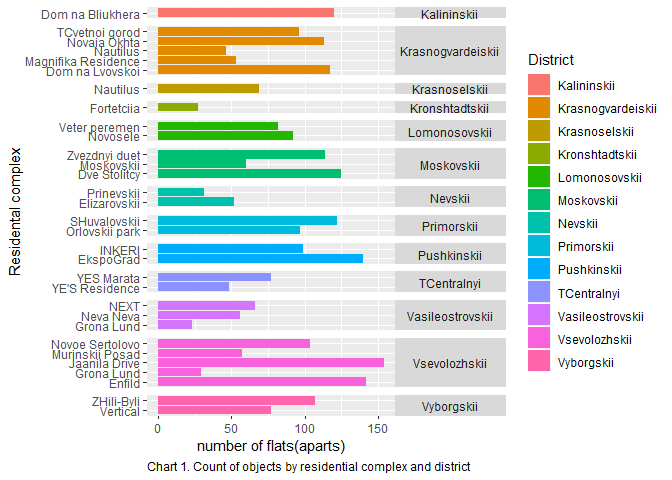

## Анализ рынка недвижимости Санкт-Петербурга

### Статистические тесты

Проверка основных показателей: цена общая за квартиру и цена за квадратный метр.

[figure not shown]

[figure not shown]

```r
#проверка на нормальность тестом Шапиро-Вилко для цены за квадратный метр
shapiro.test(data.f$za_m2)$p.value
```

```
## [1] 0.000000000000000000000000000000000000543413
```

```r
#для цены за общей
shapiro.test(data.f$TCena)$p.value
```

```
## [1] 0.0000000000000000000000000000000000000000000001863588
```

### Соотношения между параметрами квартиры и её ценой

Ниже представлены расчеты таких статистических показателей как средняя цена (mean_price), медианная цена (median_price), минимальная цена (min) и максимальная цены (max). Красным цветом были выделены те показатели средней и мединной цены, по данной переменной, которые превышают среднюю по всем полученным показателям, по каждому столбику. Синим цветом, соответственно, показатели ниже среднего. Так, можно сразу различить по две группы квартир по каждому из трех параметров - дорогие/дешевые.

#### Отношение квартиры к ЖК

| Жилой комплекс | number | mean_price | median_price | min | max |
| --- | --- | --- | --- | --- | --- |
| Dom na Bliukhera | 120 | 116096 | 113042 | 92824 | 139384 |
| Dom na Lvovskoi | 117 | 107649 | 113364 | 78611 | 127336 |
| Dve Stolitcy | 125 | 95480 | 98000 | 82000 | 105500 |
| EkspoGrad | 140 | 87222 | 88227.5 | 80179 | 93251 |
| Elizarovskii | 52 | 113456 | 112597.5 | 100747 | 137861 |
| Enfild | 142 | 87706 | 88212 | 81395 | 91364 |
| Fortetciia | 27 | 108037 | 113916 | 96305 | 115036 |
| Grona Lund | 52 | 84273 | 85351 | 68962 | 96562 |
| INKERI | 99 | 107627 | 108900 | 86850 | 126540 |
| Jaanila Drive | 154 | 72756 | 72700 | 66100 | 79900 |
| Magnifika Residence | 53 | 158248 | 158975 | 130975 | 181248 |
| Moskovskii | 60 | 95417 | 94979 | 85136 | 113024 |
| Murinskii Posad | 57 | 79186 | 78387 | 70358 | 103532 |
| Nautilus | 115 | 134206 | 135006 | 118303 | 144987 |
| Neva Neva | 56 | 166250 | 166250 | 142500 | 209000 |
| NEXT | 66 | 147803 | 143886.5 | 126134 | 190759 |
| Novaia Okhta | 113 | 86058 | 89000 | 79500 | 93000 |
| Novoe Sertolovo | 104 | 78738 | 79457.5 | 72596 | 81508 |
| Novosele | 92 | 70511 | 71000 | 67000 | 76000 |
| Orlovskii park | 97 | 94798 | 94700 | 80800 | 115900 |
| Prinevskii | 31 | 93170 | 93897 | 81449 | 101698 |
| SHuvalovskii | 122 | 100525 | 100500 | 89500 | 108000 |
| TCvetnoi gorod | 96 | 83615 | 83250 | 79000 | 88000 |
| Vertical | 77 | 172849 | 173504 | 166300 | 173504 |
| Veter peremen | 82 | 65862 | 64807.5 | 62346 | 69759 |
| YE’S Residence | 48 | 166357 | 165160 | 147840 | 204448 |
| YES Marata | 77 | 167417 | 154879 | 148869 | 196958 |
| ZHili-Byli | 107 | 107776 | 109107 | 92206 | 121596 |
| Zvezdnyi duet | 114 | 122882 | 124500 | 115500 | 128500 |

Table 1. Relation of the price to the residental complex

#### Отношение квартиры к Району

| Район | number | mean_price | median_price | min | max |
| --- | --- | --- | --- | --- | --- |
| Kalininskii | 120 | 116096 | 113042 | 92824 | 139384 |
| Krasnogvardeiskii | 425 | 105567 | 90000 | 78611 | 181248 |
| Krasnoselskii | 69 | 134802 | 136007 | 118303 | 144987 |
| Kronshtadtskii | 27 | 108037 | 113916 | 96305 | 115036 |
| Lomonosovskii | 174 | 68320 | 69000 | 62346 | 76000 |
| Moskovskii | 299 | 105915 | 101000 | 82000 | 128500 |
| Nevskii | 83 | 105879 | 104451 | 81449 | 137861 |
| Primorskii | 219 | 97988 | 99000 | 80800 | 115900 |
| Pushkinskii | 239 | 95674 | 92236 | 80179 | 126540 |
| TCentralnyi | 125 | 167010 | 162232 | 147840 | 204448 |
| Vasileostrovskii | 145 | 144437 | 147250 | 70398 | 209000 |
| Vsevolozhskii | 486 | 79969 | 79382.5 | 66100 | 103532 |
| Vyborgskii | 184 | 135008 | 119301 | 92206 | 173504 |

Table 2. Relation of the price to the district

#### Тип квартиры

| Тип квартиры | number | mean_price | median_price | min | max |
| --- | --- | --- | --- | --- | --- |
| 1A | 131 | 165465 | 173504 | 137254 | 196958 |
| 1K | 807 | 102567 | 97980 | 63804 | 204448 |
| 2A | 66 | 114645 | 88338 | 78611 | 196958 |
| 2K | 875 | 99807 | 89500 | 62346 | 209000 |
| 3K | 283 | 100174 | 93500 | 66100 | 190000 |
| SA | 40 | 153653 | 151645 | 91185 | 192979 |
| ST | 393 | 100181 | 92926 | 67965 | 179776 |

Table 3. Relation of the price to the type of flat(apart)

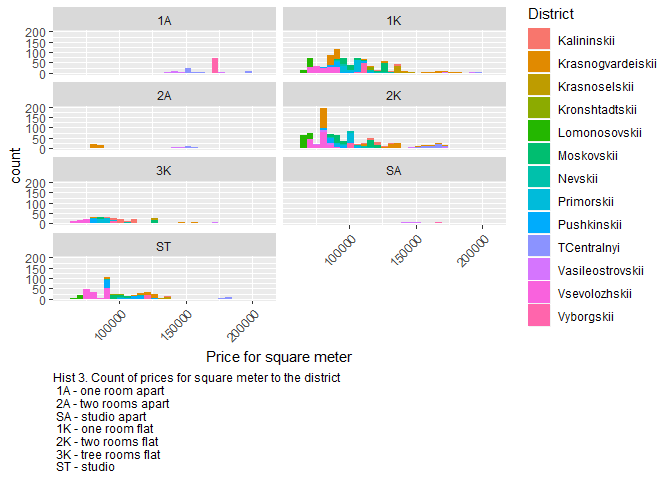

Далее я проверил, как тип материала из которого строят дом влияет на цену квартиры. На графике ниже цветом отмечены разные типы материалов из которых делаются дома. Гистограммы разбиты по отдельным застрощикам. Видно, что в каждой ячейке несколько цветов со своим распределением - это разные жилые комплексы. Судя по гистограммам, можно сказать, что материал из которого делается дом, связан с отдельным ценовым сегментом квартир. О причинной зависимости говорить нельзя, поскольку на цену жилого комплекса, в целом, оказывают так же другие значимые факторы, например, его расположение в том или ином районе. Например, монолитные дома могут стоить как относительно остальных цен дорого 147803р., так и находится в начале ценовой шкалы 65862р.

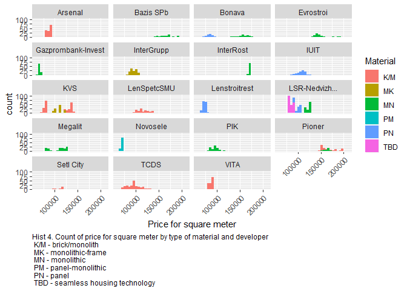

### Апартаменты

Ниже мною было произведено сравнение двух типов объектов недвижимости: апартаментов и квартир.

| type | numbers | mean_price | median_price | min_price | max_price |
| --- | --- | --- | --- | --- | --- |
| K | 2358 | 100858 | 93500 | 62346 | 209000 |
| A | 237 | 149319 | 153108 | 78611 | 196958 |

Table 4. Relation of the price to the type of flat vs apart

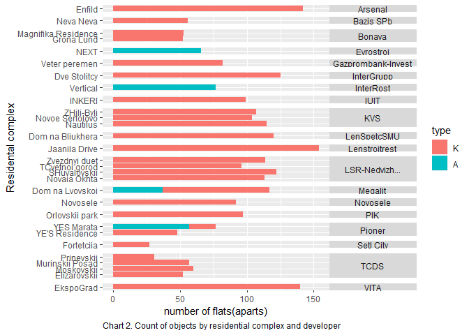

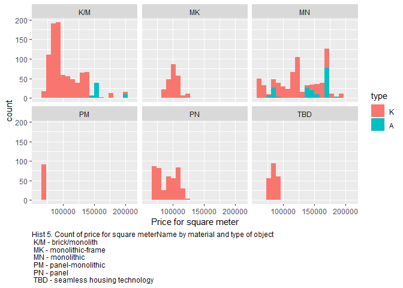

Последний график демонстрирует распределение апартов по типу материалов из которых их изготовляют. Как видно, апарты делают из материалов монолит-кирпич и монолит